# Nanodegree Machine Learnig Engineering

## Classificação de demência por parâmetros de imagens médicas estruturais do encêfalo em conjunto com testes de cognição

### Metodologia

Este projeto foi dividido nas seguintes etapas:

- Obtenção dos dados
- Normalização de dados
- Análises de outliers e correlação
- Separação de grupos de treinamento e teste
- Avaliação de classificadores
- Resultados finais

### Obtenção dos dados

```python
import pandas as pd
import matplotlib.pyplot as plt
import numpy as np

%matplotlib inline
```

Leitura do arquivo no formado CSV.

```python
df_long = pd.read_csv("./data/oasis_longitudinal.csv")
```

```python
df_long
```

|  | Subject ID | MRI ID | Group | Visit | MR Delay | M/F | Hand | Age | EDUC | SES | MMSE | CDR | eTIV | nWBV | ASF |
| --- | --- | --- | --- | --- | --- | --- | --- | --- | --- | --- | --- | --- | --- | --- | --- |
| 0 | OAS2_0001 | OAS2_0001_MR1 | Nondemented | 1 | 0 | M | R | 87 | 14 | 2.0 | 27.0 | 0.0 | 1987 | 0.696 | 0.883 |
| 1 | OAS2_0001 | OAS2_0001_MR2 | Nondemented | 2 | 457 | M | R | 88 | 14 | 2.0 | 30.0 | 0.0 | 2004 | 0.681 | 0.876 |
| 2 | OAS2_0002 | OAS2_0002_MR1 | Demented | 1 | 0 | M | R | 75 | 12 | NaN | 23.0 | 0.5 | 1678 | 0.736 | 1.046 |
| 3 | OAS2_0002 | OAS2_0002_MR2 | Demented | 2 | 560 | M | R | 76 | 12 | NaN | 28.0 | 0.5 | 1738 | 0.713 | 1.010 |
| 4 | OAS2_0002 | OAS2_0002_MR3 | Demented | 3 | 1895 | M | R | 80 | 12 | NaN | 22.0 | 0.5 | 1698 | 0.701 | 1.034 |
| 5 | OAS2_0004 | OAS2_0004_MR1 | Nondemented | 1 | 0 | F | R | 88 | 18 | 3.0 | 28.0 | 0.0 | 1215 | 0.710 | 1.444 |
| 6 | OAS2_0004 | OAS2_0004_MR2 | Nondemented | 2 | 538 | F | R | 90 | 18 | 3.0 | 27.0 | 0.0 | 1200 | 0.718 | 1.462 |
| 7 | OAS2_0005 | OAS2_0005_MR1 | Nondemented | 1 | 0 | M | R | 80 | 12 | 4.0 | 28.0 | 0.0 | 1689 | 0.712 | 1.039 |
| 8 | OAS2_0005 | OAS2_0005_MR2 | Nondemented | 2 | 1010 | M | R | 83 | 12 | 4.0 | 29.0 | 0.5 | 1701 | 0.711 | 1.032 |
| 9 | OAS2_0005 | OAS2_0005_MR3 | Nondemented | 3 | 1603 | M | R | 85 | 12 | 4.0 | 30.0 | 0.0 | 1699 | 0.705 | 1.033 |
| 10 | OAS2_0007 | OAS2_0007_MR1 | Demented | 1 | 0 | M | R | 71 | 16 | NaN | 28.0 | 0.5 | 1357 | 0.748 | 1.293 |
| 11 | OAS2_0007 | OAS2_0007_MR3 | Demented | 3 | 518 | M | R | 73 | 16 | NaN | 27.0 | 1.0 | 1365 | 0.727 | 1.286 |
| 12 | OAS2_0007 | OAS2_0007_MR4 | Demented | 4 | 1281 | M | R | 75 | 16 | NaN | 27.0 | 1.0 | 1372 | 0.710 | 1.279 |
| 13 | OAS2_0008 | OAS2_0008_MR1 | Nondemented | 1 | 0 | F | R | 93 | 14 | 2.0 | 30.0 | 0.0 | 1272 | 0.698 | 1.380 |
| 14 | OAS2_0008 | OAS2_0008_MR2 | Nondemented | 2 | 742 | F | R | 95 | 14 | 2.0 | 29.0 | 0.0 | 1257 | 0.703 | 1.396 |
| 15 | OAS2_0009 | OAS2_0009_MR1 | Demented | 1 | 0 | M | R | 68 | 12 | 2.0 | 27.0 | 0.5 | 1457 | 0.806 | 1.205 |
| 16 | OAS2_0009 | OAS2_0009_MR2 | Demented | 2 | 576 | M | R | 69 | 12 | 2.0 | 24.0 | 0.5 | 1480 | 0.791 | 1.186 |
| 17 | OAS2_0010 | OAS2_0010_MR1 | Demented | 1 | 0 | F | R | 66 | 12 | 3.0 | 30.0 | 0.5 | 1447 | 0.769 | 1.213 |
| 18 | OAS2_0010 | OAS2_0010_MR2 | Demented | 2 | 854 | F | R | 68 | 12 | 3.0 | 29.0 | 0.5 | 1482 | 0.752 | 1.184 |
| 19 | OAS2_0012 | OAS2_0012_MR1 | Nondemented | 1 | 0 | F | R | 78 | 16 | 2.0 | 29.0 | 0.0 | 1333 | 0.748 | 1.316 |
| 20 | OAS2_0012 | OAS2_0012_MR2 | Nondemented | 2 | 730 | F | R | 80 | 16 | 2.0 | 29.0 | 0.0 | 1323 | 0.738 | 1.326 |
| 21 | OAS2_0012 | OAS2_0012_MR3 | Nondemented | 3 | 1598 | F | R | 83 | 16 | 2.0 | 29.0 | 0.0 | 1323 | 0.718 | 1.327 |
| 22 | OAS2_0013 | OAS2_0013_MR1 | Nondemented | 1 | 0 | F | R | 81 | 12 | 4.0 | 30.0 | 0.0 | 1230 | 0.715 | 1.427 |
| 23 | OAS2_0013 | OAS2_0013_MR2 | Nondemented | 2 | 643 | F | R | 82 | 12 | 4.0 | 30.0 | 0.0 | 1212 | 0.720 | 1.448 |
| 24 | OAS2_0013 | OAS2_0013_MR3 | Nondemented | 3 | 1456 | F | R | 85 | 12 | 4.0 | 29.0 | 0.0 | 1225 | 0.710 | 1.433 |
| 25 | OAS2_0014 | OAS2_0014_MR1 | Demented | 1 | 0 | M | R | 76 | 16 | 3.0 | 21.0 | 0.5 | 1602 | 0.697 | 1.096 |
| 26 | OAS2_0014 | OAS2_0014_MR2 | Demented | 2 | 504 | M | R | 77 | 16 | 3.0 | 16.0 | 1.0 | 1590 | 0.696 | 1.104 |
| 27 | OAS2_0016 | OAS2_0016_MR1 | Demented | 1 | 0 | M | R | 88 | 8 | 4.0 | 25.0 | 0.5 | 1651 | 0.660 | 1.063 |
| 28 | OAS2_0016 | OAS2_0016_MR2 | Demented | 2 | 707 | M | R | 90 | 8 | 4.0 | 23.0 | 0.5 | 1668 | 0.646 | 1.052 |
| 29 | OAS2_0017 | OAS2_0017_MR1 | Nondemented | 1 | 0 | M | R | 80 | 12 | 3.0 | 29.0 | 0.0 | 1783 | 0.752 | 0.985 |
| ... | ... | ... | ... | ... | ... | ... | ... | ... | ... | ... | ... | ... | ... | ... | ... |
| 343 | OAS2_0175 | OAS2_0175_MR1 | Demented | 1 | 0 | M | R | 70 | 16 | 4.0 | 26.0 | 0.5 | 1796 | 0.742 | 0.977 |
| 344 | OAS2_0175 | OAS2_0175_MR2 | Demented | 2 | 700 | M | R | 72 | 16 | 4.0 | 28.0 | 0.5 | 1796 | 0.732 | 0.977 |
| 345 | OAS2_0175 | OAS2_0175_MR3 | Demented | 3 | 1343 | M | R | 73 | 16 | 4.0 | 28.0 | 0.5 | 1803 | 0.731 | 0.973 |
| 346 | OAS2_0176 | OAS2_0176_MR1 | Converted | 1 | 0 | M | R | 84 | 16 | 2.0 | 30.0 | 0.0 | 1404 | 0.710 | 1.250 |
| 347 | OAS2_0176 | OAS2_0176_MR2 | Converted | 2 | 774 | M | R | 87 | 16 | 2.0 | 30.0 | 0.0 | 1398 | 0.696 | 1.255 |
| 348 | OAS2_0176 | OAS2_0176_MR3 | Converted | 3 | 1631 | M | R | 89 | 16 | 2.0 | 30.0 | 0.5 | 1408 | 0.679 | 1.246 |
| 349 | OAS2_0177 | OAS2_0177_MR1 | Nondemented | 1 | 0 | M | R | 68 | 14 | 3.0 | 26.0 | 0.0 | 1444 | 0.778 | 1.216 |
| 350 | OAS2_0177 | OAS2_0177_MR2 | Nondemented | 2 | 665 | M | R | 70 | 14 | 3.0 | 28.0 | 0.0 | 1510 | 0.770 | 1.162 |
| 351 | OAS2_0178 | OAS2_0178_MR1 | Nondemented | 1 | 0 | F | R | 89 | 14 | 2.0 | 29.0 | 0.0 | 1509 | 0.756 | 1.163 |
| 352 | OAS2_0178 | OAS2_0178_MR2 | Nondemented | 2 | 600 | F | R | 90 | 14 | 2.0 | 28.0 | 0.0 | 1495 | 0.746 | 1.174 |
| 353 | OAS2_0178 | OAS2_0178_MR3 | Nondemented | 3 | 1447 | F | R | 93 | 14 | 2.0 | 30.0 | 0.0 | 1488 | 0.735 | 1.179 |
| 354 | OAS2_0179 | OAS2_0179_MR1 | Demented | 1 | 0 | M | R | 79 | 20 | 1.0 | 26.0 | 0.5 | 1548 | 0.711 | 1.134 |
| 355 | OAS2_0179 | OAS2_0179_MR2 | Demented | 2 | 652 | M | R | 81 | 20 | 1.0 | 26.0 | 0.5 | 1556 | 0.691 | 1.128 |
| 356 | OAS2_0181 | OAS2_0181_MR1 | Demented | 1 | 0 | F | R | 74 | 12 | NaN | 26.0 | 0.5 | 1171 | 0.733 | 1.499 |
| 357 | OAS2_0181 | OAS2_0181_MR2 | Demented | 2 | 539 | F | R | 75 | 12 | NaN | NaN | 1.0 | 1169 | 0.742 | 1.501 |
| 358 | OAS2_0181 | OAS2_0181_MR3 | Demented | 3 | 1107 | F | R | 77 | 12 | NaN | NaN | 1.0 | 1159 | 0.733 | 1.515 |
| 359 | OAS2_0182 | OAS2_0182_MR1 | Demented | 1 | 0 | M | R | 73 | 12 | NaN | 23.0 | 0.5 | 1661 | 0.698 | 1.056 |
| 360 | OAS2_0182 | OAS2_0182_MR2 | Demented | 2 | 776 | M | R | 75 | 12 | NaN | 20.0 | 0.5 | 1654 | 0.696 | 1.061 |
| 361 | OAS2_0183 | OAS2_0183_MR1 | Nondemented | 1 | 0 | F | R | 66 | 13 | 2.0 | 30.0 | 0.0 | 1495 | 0.746 | 1.174 |
| 362 | OAS2_0183 | OAS2_0183_MR2 | Nondemented | 2 | 182 | F | R | 66 | 13 | 2.0 | 30.0 | 0.0 | 1506 | 0.740 | 1.165 |
| 363 | OAS2_0183 | OAS2_0183_MR3 | Nondemented | 3 | 732 | F | R | 68 | 13 | 2.0 | 30.0 | 0.0 | 1506 | 0.740 | 1.165 |
| 364 | OAS2_0183 | OAS2_0183_MR4 | Nondemented | 4 | 2107 | F | R | 72 | 13 | 2.0 | 30.0 | 0.0 | 1510 | 0.723 | 1.162 |
| 365 | OAS2_0184 | OAS2_0184_MR1 | Demented | 1 | 0 | F | R | 72 | 16 | 3.0 | 24.0 | 0.5 | 1354 | 0.733 | 1.296 |
| 366 | OAS2_0184 | OAS2_0184_MR2 | Demented | 2 | 553 | F | R | 73 | 16 | 3.0 | 21.0 | 1.0 | 1351 | 0.708 | 1.299 |
| 367 | OAS2_0185 | OAS2_0185_MR1 | Demented | 1 | 0 | M | R | 80 | 16 | 1.0 | 28.0 | 0.5 | 1704 | 0.711 | 1.030 |
| 368 | OAS2_0185 | OAS2_0185_MR2 | Demented | 2 | 842 | M | R | 82 | 16 | 1.0 | 28.0 | 0.5 | 1693 | 0.694 | 1.037 |
| 369 | OAS2_0185 | OAS2_0185_MR3 | Demented | 3 | 2297 | M | R | 86 | 16 | 1.0 | 26.0 | 0.5 | 1688 | 0.675 | 1.040 |
| 370 | OAS2_0186 | OAS2_0186_MR1 | Nondemented | 1 | 0 | F | R | 61 | 13 | 2.0 | 30.0 | 0.0 | 1319 | 0.801 | 1.331 |
| 371 | OAS2_0186 | OAS2_0186_MR2 | Nondemented | 2 | 763 | F | R | 63 | 13 | 2.0 | 30.0 | 0.0 | 1327 | 0.796 | 1.323 |
| 372 | OAS2_0186 | OAS2_0186_MR3 | Nondemented | 3 | 1608 | F | R | 65 | 13 | 2.0 | 30.0 | 0.0 | 1333 | 0.801 | 1.317 |

373 rows × 15 columns

A inspeção dos dados mostra que há dados ausentes, o que indica a necessidade de verificar como contornar para não desperdiçar os dados pois o universo de amostras não é tão grande.

Atributos disponíveis

| Atributo | Definição |
| --- | --- |
| Subject ID | Identificação do paciente |
| MRI ID | Identificação do exame de RM |
| Group | Classe |
| Visit | Número da visita |
| MR Delay | Delay do exame de RM (contraste) |
| M/F | Sexo |
| Hand | Mão dominante |
| EDUC | Nível de educação |
| SES | Teste de cognição SES |
| MMSE | Teste de cognição MMSE |
| CDR | Teste de cognição CDR |
| eTIV | Volume intracraniano estimado |
| nWBV | Volume cerebral normalizado |
| ASF | Fator de escala Atlas |

Dos atributos listados, os elegíveis para classificação são:

- M/F
- Hand
- EDUC
- SES
- MMSE
- CDR
- eTIV
- nWBV
- ASF

## Normalização de dados

Busca por dados nulos.

```python
df_long.isnull().values.any()
```

```
True
```

```python
df_long.isnull().head(5)
```

|  | Subject ID | MRI ID | Group | Visit | MR Delay | M/F | Hand | Age | EDUC | SES | MMSE | CDR | eTIV | nWBV | ASF |
| --- | --- | --- | --- | --- | --- | --- | --- | --- | --- | --- | --- | --- | --- | --- | --- |
| 0 | False | False | False | False | False | False | False | False | False | False | False | False | False | False | False |
| 1 | False | False | False | False | False | False | False | False | False | False | False | False | False | False | False |
| 2 | False | False | False | False | False | False | False | False | False | True | False | False | False | False | False |
| 3 | False | False | False | False | False | False | False | False | False | True | False | False | False | False | False |
| 4 | False | False | False | False | False | False | False | False | False | True | False | False | False | False | False |

Função lâmbda para buscar, em todos atributos, possíveis valores nulos.

```python
nans = lambda df: df[df.isnull().any(axis=1)]
```

```python
nans(df_long)
```

|  | Subject ID | MRI ID | Group | Visit | MR Delay | M/F | Hand | Age | EDUC | SES | MMSE | CDR | eTIV | nWBV | ASF |
| --- | --- | --- | --- | --- | --- | --- | --- | --- | --- | --- | --- | --- | --- | --- | --- |
| 2 | OAS2_0002 | OAS2_0002_MR1 | Demented | 1 | 0 | M | R | 75 | 12 | NaN | 23.0 | 0.5 | 1678 | 0.736 | 1.046 |
| 3 | OAS2_0002 | OAS2_0002_MR2 | Demented | 2 | 560 | M | R | 76 | 12 | NaN | 28.0 | 0.5 | 1738 | 0.713 | 1.010 |
| 4 | OAS2_0002 | OAS2_0002_MR3 | Demented | 3 | 1895 | M | R | 80 | 12 | NaN | 22.0 | 0.5 | 1698 | 0.701 | 1.034 |
| 10 | OAS2_0007 | OAS2_0007_MR1 | Demented | 1 | 0 | M | R | 71 | 16 | NaN | 28.0 | 0.5 | 1357 | 0.748 | 1.293 |
| 11 | OAS2_0007 | OAS2_0007_MR3 | Demented | 3 | 518 | M | R | 73 | 16 | NaN | 27.0 | 1.0 | 1365 | 0.727 | 1.286 |
| 12 | OAS2_0007 | OAS2_0007_MR4 | Demented | 4 | 1281 | M | R | 75 | 16 | NaN | 27.0 | 1.0 | 1372 | 0.710 | 1.279 |
| 134 | OAS2_0063 | OAS2_0063_MR1 | Demented | 1 | 0 | F | R | 80 | 12 | NaN | 30.0 | 0.5 | 1430 | 0.737 | 1.228 |
| 135 | OAS2_0063 | OAS2_0063_MR2 | Demented | 2 | 490 | F | R | 81 | 12 | NaN | 27.0 | 0.5 | 1453 | 0.721 | 1.208 |
| 207 | OAS2_0099 | OAS2_0099_MR1 | Demented | 1 | 0 | F | R | 80 | 12 | NaN | 27.0 | 0.5 | 1475 | 0.762 | 1.190 |
| 208 | OAS2_0099 | OAS2_0099_MR2 | Demented | 2 | 807 | F | R | 83 | 12 | NaN | 23.0 | 0.5 | 1484 | 0.750 | 1.183 |
| 237 | OAS2_0114 | OAS2_0114_MR1 | Demented | 1 | 0 | F | R | 76 | 12 | NaN | 27.0 | 0.5 | 1316 | 0.727 | 1.333 |
| 238 | OAS2_0114 | OAS2_0114_MR2 | Demented | 2 | 570 | F | R | 78 | 12 | NaN | 27.0 | 1.0 | 1309 | 0.709 | 1.341 |
| 322 | OAS2_0160 | OAS2_0160_MR1 | Demented | 1 | 0 | M | R | 76 | 12 | NaN | 27.0 | 0.5 | 1557 | 0.705 | 1.127 |
| 323 | OAS2_0160 | OAS2_0160_MR2 | Demented | 2 | 552 | M | R | 78 | 12 | NaN | 29.0 | 1.0 | 1569 | 0.704 | 1.119 |
| 356 | OAS2_0181 | OAS2_0181_MR1 | Demented | 1 | 0 | F | R | 74 | 12 | NaN | 26.0 | 0.5 | 1171 | 0.733 | 1.499 |
| 357 | OAS2_0181 | OAS2_0181_MR2 | Demented | 2 | 539 | F | R | 75 | 12 | NaN | NaN | 1.0 | 1169 | 0.742 | 1.501 |
| 358 | OAS2_0181 | OAS2_0181_MR3 | Demented | 3 | 1107 | F | R | 77 | 12 | NaN | NaN | 1.0 | 1159 | 0.733 | 1.515 |
| 359 | OAS2_0182 | OAS2_0182_MR1 | Demented | 1 | 0 | M | R | 73 | 12 | NaN | 23.0 | 0.5 | 1661 | 0.698 | 1.056 |
| 360 | OAS2_0182 | OAS2_0182_MR2 | Demented | 2 | 776 | M | R | 75 | 12 | NaN | 20.0 | 0.5 | 1654 | 0.696 | 1.061 |

```python
len(nans(df_long))
```

```
19
```

Busca por valores outliers, neste caso valores iguais a 0.

```python
df_long.isin([0]).sum()
```

```
Subject ID      0
MRI ID          0
Group           0
Visit           0
MR Delay      150
M/F             0
Hand            0
Age             0
EDUC            0
SES             0
MMSE            0
CDR           206
eTIV            0
nWBV            0
ASF             0
dtype: int64
```

Teste de CDR igual a 0 significa sujeito saudável, é um dado normal e esperado. O MR Delay igual a 0 é que não houve espera na tomada do exame, o que também é considerado normal. Diante disto, não serão transformados nenhum outro atributo além daqueles nulos previamente apresentados.

```python
df_long["SES"].fillna(df_long["SES"].mean(), inplace=True)
df_long["MMSE"].fillna(df_long["MMSE"].mean(), inplace=True)
```

Validação se ainda existe algum dado nulo no conjunto de dados.

```python
nans(df_long)
```

|  | Subject ID | MRI ID | Group | Visit | MR Delay | M/F | Hand | Age | EDUC | SES | MMSE | CDR | eTIV | nWBV | ASF |
| --- | --- | --- | --- | --- | --- | --- | --- | --- | --- | --- | --- | --- | --- | --- | --- |

## Análise de outliers e correlação

Função para geração de gráficos de contagem para verificação de ouliers em aspecto visual.

```python
import matplotlib.pyplot as plt
import matplotlib

matplotlib.rc('xtick', labelsize=20)
matplotlib.rc('ytick', labelsize=20)
```

```python
import seaborn as sns
import matplotlib.pyplot as plt
import matplotlib.ticker as ticker
from pandas import DataFrame
import pandas as pd

def generate_chars(field):
    #plt.figure()

    sns.set(font_scale = 1.5)

    if field == "MR Delay":
        df_query_mri = df_long[df_long["MR Delay"] > 0]
        g = sns.countplot(df_query_mri["MR Delay"])
        g.figure.set_size_inches(18.5, 10.5)
    else:
        fig, ax = plt.subplots(1,2)

        df_chart_dem = df_long[df_long["Group"]=="Demented"]
        df_chart_ndem = df_long[df_long["Group"]=="Nondemented"]

        ax[0].set_title(str(item) + " Demented", fontsize=20)
        ax[1].set_title(str(item) + " Nondemented", fontsize=20)

        g1 = sns.countplot(x=item, data=df_chart_dem, ax=ax[0])
        g2 = sns.countplot(x=item, data=df_chart_ndem, ax=ax[1])

        g1.set_ylabel("Quantidade",fontsize=17)
        g2.set_ylabel("Quantidade",fontsize=17)

        g1.set_xlabel("Sujeitos", fontsize=17)
        g2.set_xlabel("Sujeitos", fontsize=17)



        if item in ["Age", "eTIV", "nWBV", "ASF", "MMSE"]:


            if item in ["MMSE", "Age"]:
                g2.xaxis.set_major_locator(ticker.MultipleLocator(2))
                g1.xaxis.set_major_locator(ticker.MultipleLocator(2))
            else:
                g1.xaxis.set_major_formatter(ticker.ScalarFormatter())
                g2.xaxis.set_major_formatter(ticker.ScalarFormatter())
                g2.xaxis.set_major_locator(ticker.MultipleLocator(12))
                g1.xaxis.set_major_locator(ticker.MultipleLocator(12))


        g1.figure.set_size_inches(18.5, 10.5)
        g2.figure.set_size_inches(18.5, 10.5)

        #fig.show()



sns.despine()
```

Criando o mapeamento paramétrico com dicionários para campos de classes.

```python
list_atributes = ["M/F", "Age", "EDUC", "SES", "MMSE", "CDR", "eTIV", "nWBV", "ASF"]
```

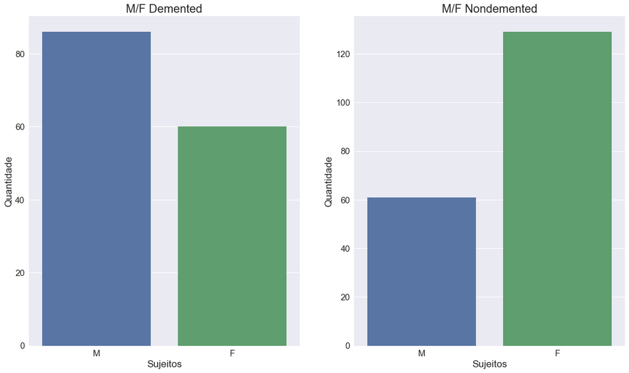

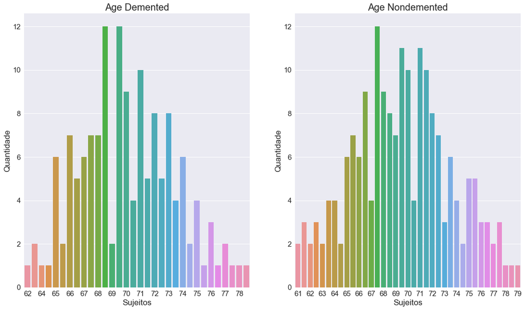

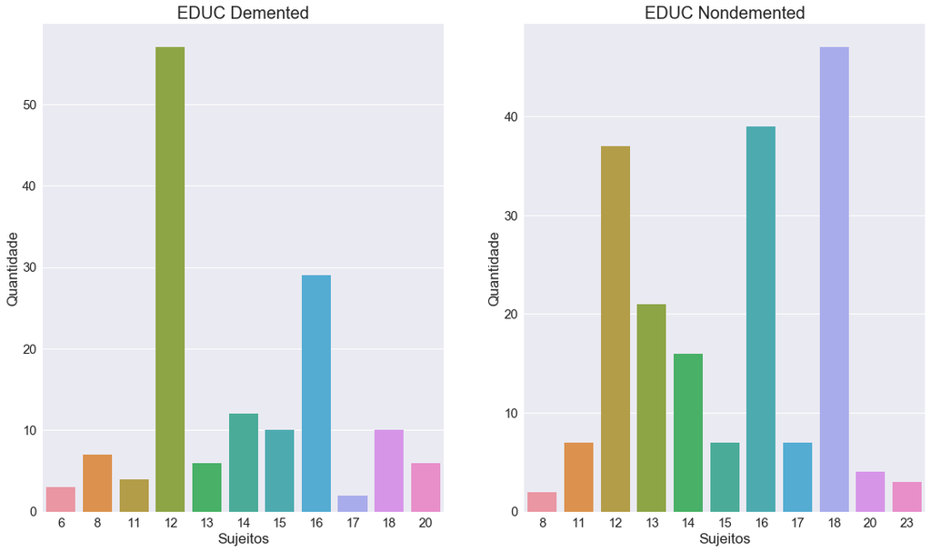

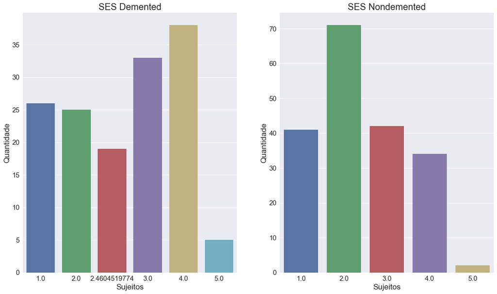

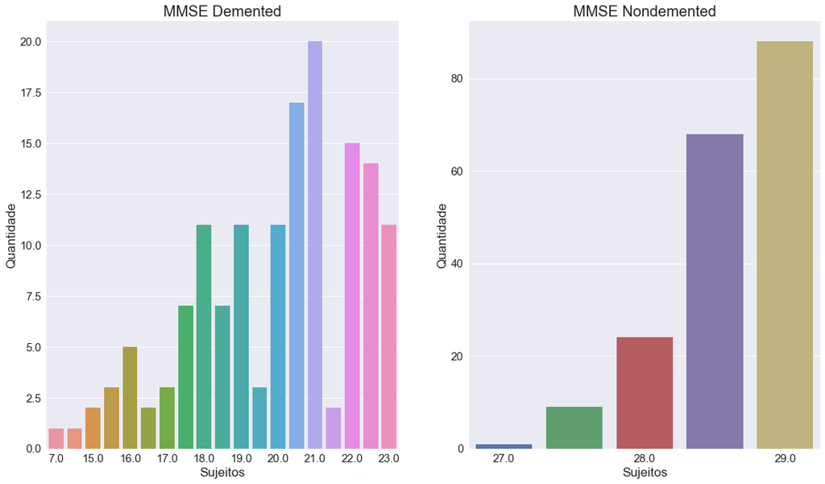

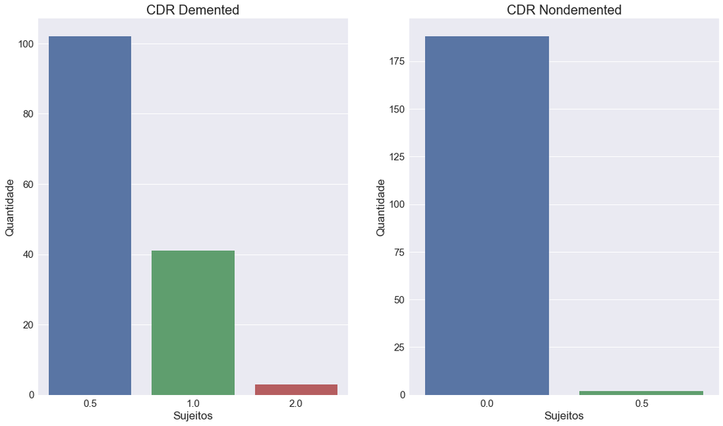

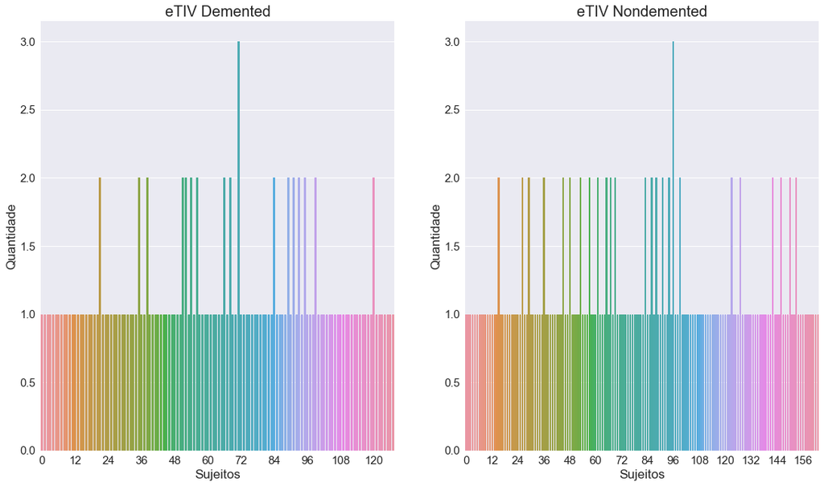

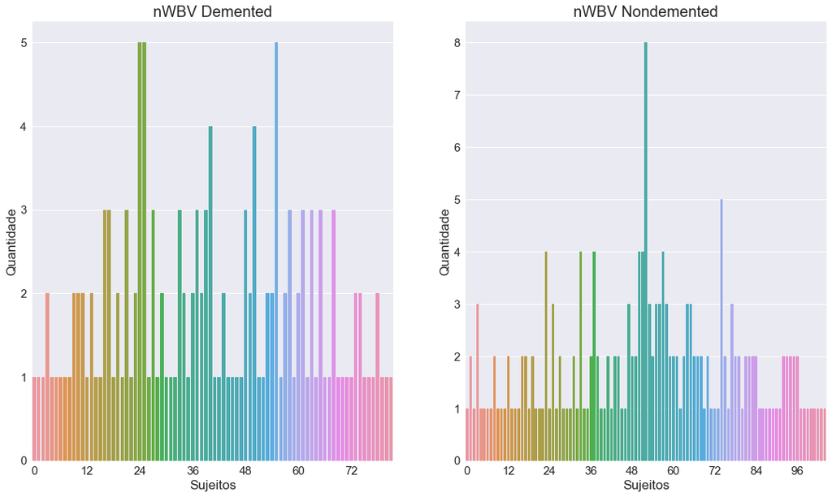

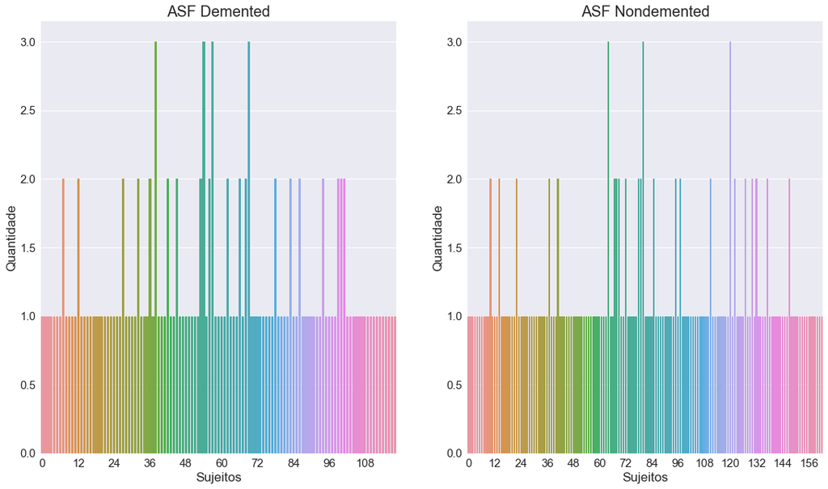

```python
for item in list_atributes:
    generate_chars(item)
```

```python
group_map = {"Demented": 1, "Nondemented": 0}
gender_map = {"M": 1, "F": 0}
hand_map = {"R": 1, "L": 0}

df_long['Group'] = df_long['Group'].replace(['Converted'], ['Demented'])

df_long['Group'] = df_long['Group'].map(group_map)
df_long['M/F'] = df_long['M/F'].map(gender_map)
df_long['Hand'] = df_long['Hand'].map(hand_map)
```

Remoção do atributo "Hand" por não haver variação e o atributo "MR Delay" por não haver nenhuma causa associada, pois tal atributo indica contraste do exame de ressonânica magnética.

```python
list_atributes = ["M/F", "Age", "EDUC", "SES", "MMSE", "CDR", "eTIV", "nWBV", "ASF"]
```

```python
for item in list_atributes:
    print("Atributo: %s, Outliers %s: "%(item,outliers_z_score(df_long[item])))
```

```
Atributo: M/F, Outliers (array([], dtype=int64),):
Atributo: Age, Outliers (array([], dtype=int64),):
Atributo: EDUC, Outliers (array([], dtype=int64),):
Atributo: SES, Outliers (array([], dtype=int64),):
Atributo: MMSE, Outliers (array([ 26,  89, 100, 101, 172, 173, 251]),):
Atributo: CDR, Outliers (array([184, 251, 330]),):
Atributo: eTIV, Outliers (array([], dtype=int64),):
Atributo: nWBV, Outliers (array([], dtype=int64),):
Atributo: ASF, Outliers (array([], dtype=int64),):
```

Diante dos gráficos e das análises de Z Score não foram encontrados outliers suficientes para serem removidos do conjunto de dados. Os dados estão coerentes e não representam nenhum viés latente.

Verificação de correlação

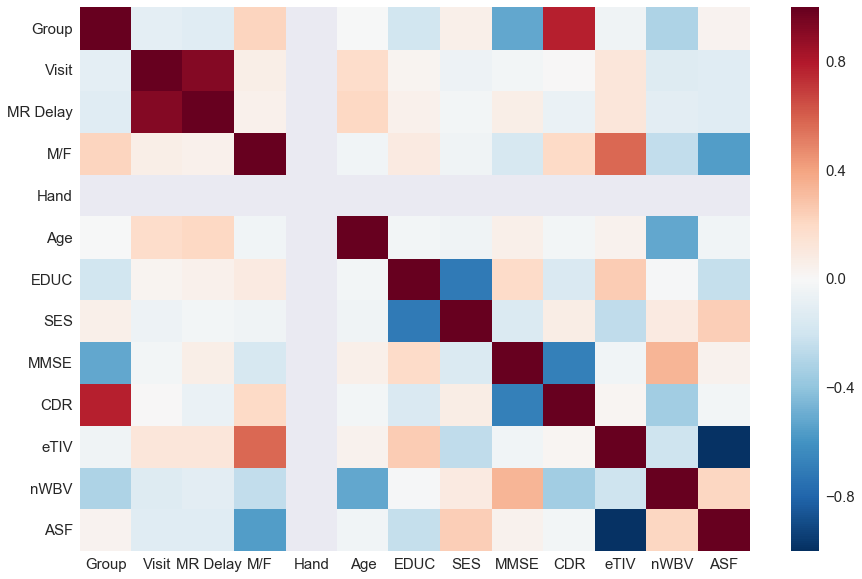

```python
from pylab import rcParams
rcParams['figure.figsize'] = 8, 5

corr_matrix = df_long.corr()
rcParams['figure.figsize'] = 15, 10
sns.heatmap(corr_matrix)
```

```python
df_long.corr()
```

|  | Group | Visit | MR Delay | M/F | Hand | Age | EDUC | SES | MMSE | CDR | eTIV | nWBV | ASF |
| --- | --- | --- | --- | --- | --- | --- | --- | --- | --- | --- | --- | --- | --- |
| Group | 1.000000 | -0.095507 | -0.120638 | 0.222146 | NaN | -0.005941 | -0.193060 | 0.060697 | -0.523305 | 0.778049 | -0.042700 | -0.311346 | 0.032495 |
| Visit | -0.095507 | 1.000000 | 0.920009 | 0.069791 | NaN | 0.183213 | 0.024615 | -0.050422 | -0.029020 | 0.002325 | 0.117428 | -0.126682 | -0.120399 |
| MR Delay | -0.120638 | 0.920009 | 1.000000 | 0.048006 | NaN | 0.205357 | 0.051630 | -0.030258 | 0.065786 | -0.062915 | 0.119624 | -0.105586 | -0.123545 |
| M/F | 0.222146 | 0.069791 | 0.048006 | 1.000000 | NaN | -0.037726 | 0.089279 | -0.044525 | -0.166521 | 0.202140 | 0.572549 | -0.249618 | -0.561647 |
| Hand | NaN | NaN | NaN | NaN | NaN | NaN | NaN | NaN | NaN | NaN | NaN | NaN | NaN |
| Age | -0.005941 | 0.183213 | 0.205357 | -0.037726 | NaN | 1.000000 | -0.027886 | -0.046665 | 0.055607 | -0.026257 | 0.042348 | -0.518359 | -0.035067 |
| EDUC | -0.193060 | 0.024615 | 0.051630 | 0.089279 | NaN | -0.027886 | 1.000000 | -0.708680 | 0.194454 | -0.153121 | 0.257015 | -0.012200 | -0.241752 |
| SES | 0.060697 | -0.050422 | -0.030258 | -0.044525 | NaN | -0.046665 | -0.708680 | 1.000000 | -0.146913 | 0.073393 | -0.254271 | 0.089436 | 0.246673 |
| MMSE | -0.523305 | -0.029020 | 0.065786 | -0.166521 | NaN | 0.055607 | 0.194454 | -0.146913 | 1.000000 | -0.679837 | -0.031789 | 0.341857 | 0.039494 |
| CDR | 0.778049 | 0.002325 | -0.062915 | 0.202140 | NaN | -0.026257 | -0.153121 | 0.073393 | -0.679837 | 1.000000 | 0.022819 | -0.344819 | -0.029340 |
| eTIV | -0.042700 | 0.117428 | 0.119624 | 0.572549 | NaN | 0.042348 | 0.257015 | -0.254271 | -0.031789 | 0.022819 | 1.000000 | -0.210122 | -0.988877 |
| nWBV | -0.311346 | -0.126682 | -0.105586 | -0.249618 | NaN | -0.518359 | -0.012200 | 0.089436 | 0.341857 | -0.344819 | -0.210122 | 1.000000 | 0.213476 |
| ASF | 0.032495 | -0.120399 | -0.123545 | -0.561647 | NaN | -0.035067 | -0.241752 | 0.246673 | 0.039494 | -0.029340 | -0.988877 | 0.213476 | 1.000000 |

Os atributos que serão utilizados para construir o modelo de classificação serão:

- M/F
- Age
- EDUC
- SES
- MMSE
- CDR
- eTIV
- nWBC
- ASF

Os demais não serão utilizados nesse momento. Posteriormente será utilizado o número de visitas em uma medida de acompanhamento de evolução do classificador, criando um paralelo com a evolução da DA nos sujeitos.

### Separação de grupos de treinamento e teste

Função para exibição de Confusion Matrix mais detalhada, na forma gráfica.

```python
def show_confusion_matrix(C,class_labels=['0','1']):
    """
    C: ndarray, shape (2,2) as given by scikit-learn confusion_matrix function
    class_labels: list of strings, default simply labels 0 and 1.

    Draws confusion matrix with associated metrics.
    """
    import matplotlib.pyplot as plt
    import numpy as np

    assert C.shape == (2,2), "Confusion matrix should be from binary classification only."

    # true negative, false positive, etc...
    tn = C[0,0]; fp = C[0,1]; fn = C[1,0]; tp = C[1,1];

    NP = fn+tp # Num positive examples
    NN = tn+fp # Num negative examples
    N  = NP+NN

    fig = plt.figure(figsize=(8,8))
    ax  = fig.add_subplot(111)
    ax.imshow(C, interpolation='nearest', cmap=plt.cm.gray)

    # Draw the grid boxes
    ax.set_xlim(-0.5,2.5)
    ax.set_ylim(2.5,-0.5)
    ax.plot([-0.5,2.5],[0.5,0.5], '-k', lw=2)
    ax.plot([-0.5,2.5],[1.5,1.5], '-k', lw=2)
    ax.plot([0.5,0.5],[-0.5,2.5], '-k', lw=2)
    ax.plot([1.5,1.5],[-0.5,2.5], '-k', lw=2)

    # Set xlabels
    ax.set_xlabel('Predicted Label', fontsize=16)
    ax.set_xticks([0,1,2])
    ax.set_xticklabels(class_labels + [''])
    ax.xaxis.set_label_position('top')
    ax.xaxis.tick_top()
    # These coordinate might require some tinkering. Ditto for y, below.
    ax.xaxis.set_label_coords(0.34,1.06)

    # Set ylabels
    ax.set_ylabel('True Label', fontsize=16, rotation=90)
    ax.set_yticklabels(class_labels + [''],rotation=90)
    ax.set_yticks([0,1,2])
    ax.yaxis.set_label_coords(-0.09,0.65)


    # Fill in initial metrics: tp, tn, etc...
    ax.text(0,0,
            'True Neg: %d\n(Num Neg: %d)'%(tn,NN),
            va='center',
            ha='center',
            fontsize=16,
            bbox=dict(fc='w',boxstyle='round,pad=1'))

    ax.text(0,1,
            'False Neg: %d'%fn,
            va='center',
            ha='center',
            fontsize=16,
            bbox=dict(fc='w',boxstyle='round,pad=1'))

    ax.text(1,0,
            'False Pos: %d'%fp,
            va='center',
            ha='center',
            fontsize=16,
            bbox=dict(fc='w',boxstyle='round,pad=1'))


    ax.text(1,1,
            'True Pos: %d\n(Num Pos: %d)'%(tp,NP),
            va='center',
            ha='center',
            fontsize=16,
            bbox=dict(fc='w',boxstyle='round,pad=1'))

    # Fill in secondary metrics: accuracy, true pos rate, etc...
    ax.text(2,0,
            'False Pos Rate: %.2f'%(fp / (fp+tn+0.)),
            va='center',
            ha='center',
            fontsize=16,
            bbox=dict(fc='w',boxstyle='round,pad=1'))

    ax.text(2,1,
            'True Pos Rate: %.2f'%(tp / (tp+fn+0.)),
            va='center',
            ha='center',
            fontsize=16,
            bbox=dict(fc='w',boxstyle='round,pad=1'))

    ax.text(2,2,
            'Accuracy: %.2f'%((tp+tn+0.)/N),
            va='center',
            ha='center',
            fontsize=16,
            bbox=dict(fc='w',boxstyle='round,pad=1'))

    ax.text(0,2,
            'Neg Pre Val: %.2f'%(1-fn/(fn+tn+0.)),
            va='center',
            ha='center',
            fontsize=16,
            bbox=dict(fc='w',boxstyle='round,pad=1'))

    ax.text(1,2,
            'Pos Pred Val: %.2f'%(tp/(tp+fp+0.)),
            va='center',
            ha='center',
            fontsize=16,
            bbox=dict(fc='w',boxstyle='round,pad=1'))


    plt.tight_layout()
    plt.show()
```

Separação dos grupos de treinamento e teste, sendo a razão de 30% para testes e 70% para treinamento.

```python
from sklearn.model_selection import train_test_split

feature_col_names = ["M/F", "Age", "EDUC", "SES", "CDR", "MMSE", "eTIV", "nWBV", "ASF"]
predicted_class_names = ['Group']

X = df_long[feature_col_names].values
y = df_long[predicted_class_names].values

split_test_size = 0.30

X_train, X_test, y_train, y_test = train_test_split(X, y, test_size=split_test_size, random_state=42)
```

```python
print("{0:0.2f}% para Treinamento".format((len(X_train)/len(df_long.index)) * 100))
print("{0:0.2f}% para Testes".format((len(X_test)/len(df_long.index)) * 100))
```

```
69.97% para Treinamento
30.03% para Testes
```

Distribuição dos dados

```python
print("Original Demented : {0} ({1:0.2f}%)".format(len(df_long.loc[df_long['Group'] == 1]), 100 * (len(df_long.loc[df_long['Group'] == 1]) / len(df_long))))
print("Original Nondemented : {0} ({1:0.2f}%)".format(len(df_long.loc[df_long['Group'] == 0]), 100 * (len(df_long.loc[df_long['Group'] == 0]) / len(df_long))))
print("")
print("Training Demented : {0} ({1:0.2f}%)".format(len(y_train[y_train[:] == 1]), 100 * (len(y_train[y_train[:] == 1]) / len(y_train))))
print("Training Nondemented : {0} ({1:0.2f}%)".format(len(y_train[y_train[:] == 0]), 100 * (len(y_train[y_train[:] == 0]) / len(y_train))))
print("")
print("Test Demented : {0} ({1:0.2f}%)".format(len(y_test[y_test[:] == 1]), 100 * (len(y_test[y_test[:] == 1]) / len(y_test))))
print("Test Nondemented : {0} ({1:0.2f}%)".format(len(y_test[y_test[:] == 0]), 100 * (len(y_test[y_test[:] == 0]) / len(y_test))))
```

```
Original Demented : 183 (49.06%)
Original Nondemented : 190 (50.94%)

Training Demented : 123 (47.13%)
Training Nondemented : 138 (52.87%)

Test Demented : 60 (53.57%)
Test Nondemented : 52 (46.43%)
```

```
Feature ranking:

1. feature 7 M/F (16.997238)
2. feature 8 Age (12.963198)
3. feature 6 EDUC (12.264228)
4. feature 3 SES (11.793812)
5. feature 4 CDR (11.699981)
6. feature 2 MMSE (9.384370)
7. feature 0 eTIV (8.681000)
8. feature 5 nWBV (8.401604)
9. feature 1 ASF (7.814569)
```

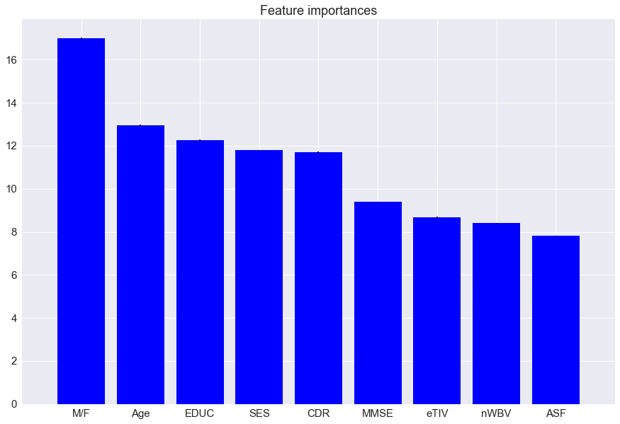

```python
import numpy as np
import matplotlib.pyplot as plt

from sklearn.datasets import make_classification
from sklearn.ensemble import ExtraTreesClassifier

# Build a classification task using 3 informative features
X, y = make_classification(n_samples=1000, n_features=len(feature_col_names),
                           n_informative=len(feature_col_names), n_redundant=0, n_repeated=0,
                           n_classes=2, random_state=0, shuffle=False)

# Build a forest and compute the feature importances
forest = ExtraTreesClassifier(n_estimators=250, random_state=0)

forest.fit(X, y)
importances = forest.feature_importances_*100
std = np.std([tree.feature_importances_ for tree in forest.estimators_], axis=0)
indices = np.argsort(importances)[::-1]

# Print the feature ranking
print("Feature ranking:\n")

for f in range(X.shape[1]):
    print("%d. feature %d %s (%f)" % (f + 1, indices[f], feature_col_names[f], importances[indices[f]]))

col_name = lambda x : feature_col_names[x]

# Plot the feature importances of the forest
plt.figure()
plt.title("Feature importances")
plt.bar(range(X.shape[1]), importances[indices], color="b", yerr=std[indices], align="center")
plt.xticks(range(X.shape[1]), list(map(col_name,range(X.shape[1]))))
plt.xlim([-1, X.shape[1]])
plt.show()
```